# Fig6_inhibitor_gradient

## Lateral induction in a gradient of diffusible inhibitor

### Set up environment

```python
%load_ext blackcellmagic
```

```python
import lateral_signaling as lsig
import numpy as np
import pandas as pd
import numba

import holoviews as hv
hv.extension("matplotlib")

import colorcet as cc
```

## Modeling lateral signaling under a gradient of inhibitor

Soluble ligand has been shown to inhibit activation of SynNotch receptors via an unknown mechanism. We hypothesized that a population of GFP-secreting cells could inhibit transceivers via diffusible (morphogen) signaling, producing a boundary-like domain.

To understand whether our model can generate this behavior, we simulate lateral induction signaling under an inhibitor gradient.

#### Modeling a gradient of diffusible inhibitor

Consider a 1-dimensional fluid chamber over $x\in[0,\infty]$ containing a soluble inhibitor species $\mathrm{I}$ with concentration $I(x)$. Let us further assume $\mathrm{I}$ is produced by a point source $x=0$ at a constant rate, decays to $I=0$ as $x\rightarrow \infty$, and is degraded at a constant rate. At stationarity ($\partial I / \partial t=0$), the steady-state solution to this diffusion problem can be shown to take the exponential form

\begin{align} I(x) = I_0 e^{-b x}, \\ \end{align}

where $I_0$ and $b$ depend on the diffusion constant of $\mathrm{I}$, the decay rate, and the source production rate.

```python
@numba.njit
def I_x_exp(x, I0, b):
    """Inhibitor concentration (exponential gradient)"""
    return np.exp(-b * x)
```

#### Modeling and parameterizing competitive inhibition

```python
def tc_rhs_3_inhib(S, S_delay, Adj, sender_idx, I, alpha, k, p, ell, delta, beta):
    """
    """

    # Get input signal across each interface
    S_bar = beta * ell * (Adj @ S_delay)

    # Set perimeter at density = 1
    P0 = 6 / np.sqrt(3)

    # Calculate dE/dt
    dS_dt = (
        alpha
        * (S_bar ** p)
        / ((P0 * k) ** p + (P0 * delta * (S_delay + I)) ** p + S_bar ** p)
        - S
    )

    # Set sender cell to zero
    dS_dt[sender_idx] = 0

    return dS_dt


def tc_rhs_3_noinhib(S, S_delay, Adj, sender_idx, I, alpha, k, p, ell, delta, beta):
    """
    """

    # Get input signal across each interface
    S_bar = beta * ell * (Adj @ S_delay)

    # Set perimeter at density = 1
    P0 = 6 / np.sqrt(3)

    # Calculate dE/dt
    dS_dt = (
        alpha
        * (S_bar ** p)
        / ((P0 * k) ** p + (P0 * delta * S_delay) ** p + S_bar ** p)
        - S
    )

    # Set sender cell to zero
    dS_dt[sender_idx] = 0

    return dS_dt

def get_rhs(Adj, sender_idx, I, func):
    def rhs(S, S_delay, *args):
        return func(S, S_delay, Adj, sender_idx, I, *args)

    return rhs
```

We seed $n$ cells in a hexagonal grid of dimensions $x\in[0,L], y\in[0,L/4]$ for some length $L$. We use non-periodic and periodic boundary conditions in the $x$- and $y$-direction, respectively (cylindrical topology). The adjacency matrix

\begin{align} A_{ij}=(a_{ij})= \begin{cases} 1 & \text{cell } j\neq i \text{ is adjacent to cell }i \\ 0 & \text{else} \\ \end{cases} \end{align}

encodes cell-cell adjacency and is stored in sparse format using `scipy.sparse.csr_matrix` for efficient storage and computation.

```python
# Make lattice and get adjacency matrix
L = 400
rows, cols = int(L/4), int(L)
r = 1.   # cell-cell distance
X, Adj = lsig.hex_Adj(rows, cols, r=r, sparse=True)

# Shift coordinates to be nonnegative
X = X - X.min(axis=0)

# Get # cells
n = X.shape[0]

# Remove periodic boundaries in x-direction
Adj[:rows, -rows:] = 0
Adj[-rows:, :rows] = 0
```

To parameterize $I(x)$, we assume the inhibitor starts at concentration $I_0=1$ and decays by a factor of $1/2$ over a length $L/8$.

\begin{align} I(x)=e^{-\frac{8 \ln{2}}{L}\,x} \end{align}

```python
# Get inhibitor concentration
I0, b = 1, 8 * np.log(2) / L
I = I_x_exp(X[:, 0], I0, b)
```

#### Simulating signaling

We set the time-window long enough to capture any interesting long-term dynamics.

```python
# Set time parameters
tmax = 3
nt_t = 100
nt = int(nt_t * tmax) + 1
t = np.linspace(0, tmax, nt)
```

We randomly assign $1\%$ of cells to be senders to mimic the $\text{1:100}$ ratio in the experiment.

```python
# Specify percent of population that is sender
pct_s = 1
n_s = int(n * (pct_s/100)) + 1

# Set seed
np.random.seed(1)

# Assign senders randomly
sender_idx = np.random.choice(n, n_s, replace=False)
```

We use our example parameter set

```python
# Set signaling parameters
alpha = 3
k = 0.12
p = 2
delta = 2
beta = 1.

delay = 0.4

ell = r / np.sqrt(3)

# Package parameters
args = (alpha, k, p, ell, delta, beta)
```

To compare results with and without the inhibitor, we define two RHS functions.

```python
# Get RHS with inhibitor
rhs_inhib = get_rhs(Adj, sender_idx, I, tc_rhs_3_inhib)

# Get RHS without inhibitor
rhs_noinhib = get_rhs(Adj, sender_idx, I, tc_rhs_3_noinhib)
```

We initialize transceivers and senders at fluorescence values of $0$ and $1$, respectively.

```python
# Initialize fluorescence
S0 = np.zeros(n, dtype=np.float32)
S0[sender_idx] = 1

# Simulate
S_t_inhib = lsig.integrate_DDE(
    t,
    rhs_inhib,
    dde_args=args,
    E0=S0,
    delay=delay,
    progress_bar=True,
    min_delay=5,
)

S_t_noinhib = lsig.integrate_DDE(
    t,
    rhs_noinhib,
    dde_args=args,
    E0=S0,
    delay=delay,
    progress_bar=True,
    min_delay=5,
)
```

#### Visualizing a simulated inhibitor gradient

To visualize fluorescence of many cells, we will treat each cell centroid as a point in a `ColorMesh` object and use `lsig.inspect_colormesh()` to render a continuous, interpolated heatmap.

Below, we plot each cell's fluorescence over time in each condition.

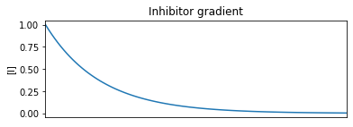

```python
import matplotlib.pyplot as plt
%matplotlib inline

# Set dimensions for a grid of frames
nrows, ncols = 1, 1

# Render frames
nplot = nrows * ncols
idx = [int(i) for i in np.linspace(0, nt-1, nplot)]
fig, ax = plt.subplots(
    nrows=nrows, ncols=ncols, figsize=(6 * ncols, 2 * nrows)
)
title="Inhibitor gradient"

x_plot=np.linspace(X[:,0].min(), X[:, 0].max(), 100)
I_plot=I_x_exp(x_plot, I0, b)

ax.plot(x_plot, I_plot)
ax.set_title(title)
ax.set_ylabel("[I]")
ax.set_xlim((X[:,0].min(), X[:, 0].max()))
ax.xaxis.set_visible(False)
```

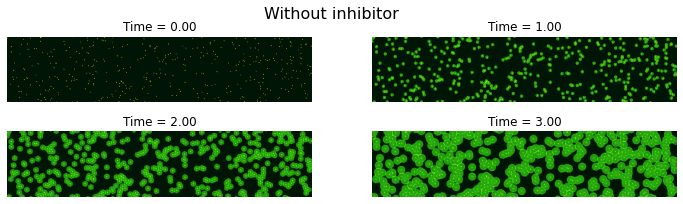

```python
import matplotlib.pyplot as plt
%matplotlib inline

# Set dimensions for a grid of frames
nrows, ncols = 2, 2

# Render frames
nplot = nrows * ncols
idx = [int(i) for i in np.linspace(0, nt-1, nplot)]
fig, axs = plt.subplots(
    nrows=nrows, ncols=ncols, figsize=(6 * ncols, 1.6 * nrows)
)
for ax, i in zip(axs.flat, idx):
    title=f"Time = {t[i]:.2f}"
    lsig.inspect_colormesh(
        ax=ax,
        X=X,
        rows=rows,
        cols=cols,
        var=S_t_noinhib,
        idx=i,
        vmin=0,
        vmax=1,
        cmap="kgy",
        title=title,
        axis_off=True
    )

fig.suptitle("Without inhibitor", fontsize=16);
```

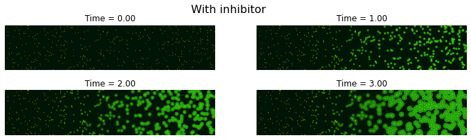

```python
import matplotlib.pyplot as plt
%matplotlib inline

# Set dimensions for a grid of frames
nrows, ncols = 2, 2

# Render frames
nplot = nrows * ncols
idx = [int(i) for i in np.linspace(0, nt-1, nplot)]
fig, axs = plt.subplots(
    nrows=nrows, ncols=ncols, figsize=(6 * ncols, 1.6 * nrows)
)
for ax, i in zip(axs.flat, idx):
    title=f"Time = {t[i]:.2f}"
    lsig.inspect_colormesh(
        ax=ax,
        X=X,
        rows=rows,
        cols=cols,
        var=S_t_inhib,
        idx=i,
        vmin=0,
        vmax=1,
        cmap="kgy",
#         xlim=xlim,
#         ylim=ylim,
        title=title,
        axis_off=True
    )

fig.suptitle("With inhibitor", fontsize=16);
```

The inhibitor produces inactive and activated domains, with a relatively sharp boundary. Below we plot the final fluorescence values side-by-side

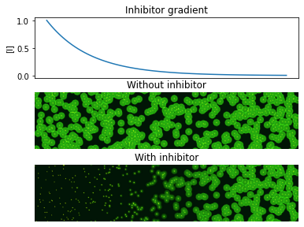

```python
import matplotlib.pyplot as plt
%matplotlib inline

# Set dimensions for a grid of frames
nrows, ncols = 3, 1

# Render frames
nplot = nrows * ncols
fig, axs = plt.subplots(
    nrows=nrows, ncols=ncols, figsize=(6 * ncols, 1.6 * nrows)
)

x_plot=np.linspace(X[:,0].min(), X[:, 0].max(), 100)
I_plot=I_x_exp(x_plot, I0, b)

axs[0].plot(x_plot, I_plot)
axs[0].set_title("Inhibitor gradient")
axs[0].set_ylabel("[I]")
ax.set_xlim((X[:,0].min(), X[:, 0].max()))
axs[0].xaxis.set_visible(False)

lsig.inspect_colormesh(
        ax=axs[1],
        X=X,
        rows=rows,
        cols=cols,
        var=S_t_noinhib,
        idx=nt-1,
        vmin=0,
        vmax=1,
        cmap="kgy",
        title="Without inhibitor",
        axis_off=True
    )

lsig.inspect_colormesh(
        ax=axs[2],
        X=X,
        rows=rows,
        cols=cols,
        var=S_t_inhib,
        idx=nt-1,
        vmin=0,
        vmax=1,
        cmap="kgy",
        title="With inhibitor",
        axis_off=True
    )
```

### Save figures

```python
import os

dirname = "plots"
print("dir exists?", os.path.exists(dirname))

fname = "inhib_grad_I0{0:.2f}_b{1:.2f}_{2:.1f}pctsender".format(
    I0, b, pct_s
)

fmt="png"

fname = os.path.join(dirname, fname) + "." + fmt
```

```
dir exists? True
```

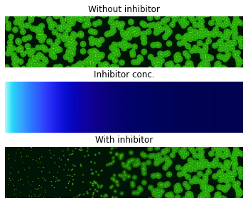

```python
import matplotlib.pyplot as plt
%matplotlib inline

# Set dimensions for a grid of frames
nrows, ncols = 3, 1

# Render frames
nplot = nrows * ncols
fig, axs = plt.subplots(
    nrows=nrows, ncols=ncols, figsize=(6 * ncols, 1.6 * nrows)
)

lsig.inspect_colormesh(
        ax=axs[0],
        X=X,
        rows=rows,
        cols=cols,
        var=S_t_noinhib,
        idx=nt-1,
        vmin=0,
        vmax=1,
        cmap="kgy",
        title="Without inhibitor",
        axis_off=True
    )

lsig.inspect_colormesh(
        ax=axs[1],
        X=X,
        rows=rows,
        cols=cols,
        var=I,
        idx=0,
        vmin=0,
        vmax=1,
        cmap="kbc",
        title="Inhibitor conc.",
        axis_off=True
    )

lsig.inspect_colormesh(
        ax=axs[2],
        X=X,
        rows=rows,
        cols=cols,
        var=S_t_inhib,
        idx=nt-1,
        vmin=0,
        vmax=1,
        cmap="kgy",
        title="With inhibitor",
        axis_off=True
    )

plt.savefig(fname, dpi=150, format=fmt)
```